# 第25回 事前学習

作者

J22069 野倉悠正

# サーバーへのデプロイメント

流れとしては以下の通り。

1. 自分のPCでDocker Hubにイメージのプッシュ
2. サーバーにSSH接続
3. サーバー上でDockerにログイン
4. イメージをDocker Hubからプル
5. Apptainerを使ってSIFファイルに変換
6. フロントエンドのSIFファイルから静的ファイルを取り出す
7. Apptainerのインスタンスの起動
8. Webサーバーの起動（Gunicorn）

## Docker Hubにイメージをプッシュ

### イメージのビルド

```
bash
```

```bash
# docker build <ディレクトリ> -t <イメージ名>
docker build ~/shinshu-fesnav/backend -t shinshu-fesnav-backend
docker build ~/shinshu-fesnav/frontend -t shinshu-fesnav-frontend
```

**ノート**

イメージが正常に作成されたか確認するには、以下を実行。

```
bash
```

```bash
docker images
```

### イメージのタグ付け

```
bash
```

```bash
# docker tag <イメージ名> <リポジトリ>:<タグ>
docker tag shinshu-fesnav-backend yumachin2003/shinshu-fesnav-backend:v0
docker tag shinshu-fesnav-frontend yumachin2003/shinshu-fesnav-frontend:v0
```

`:v0`の部分がリポジトリ上のタグになり、一般的にはバージョン番号を付加する。

### イメージのプッシュ

**重要**

非公開リポジトリを含む場合、あらかじめDocker Hubアカウントでのログインが必要である。

```
bash
```

```bash
# docker push <リポジトリ>:<タグ>
docker push yumachin2003/shinshu-fesnav-backend:v0
docker push yumachin2003/shinshu-fesnav-frontend:v0
```

## Docker Hubへのログイン

プッシュするリポジトリが非公開の場合、ログインの必要がある。

```
bash
```

```bash
docker login -u <username>
```

`Login Succeeded`の表示でログイン完了。

**重要**

`-p`オプションでパスワードを指定することもできるが、（特にサーバーの場合）`.bash_history`にコマンドの履歴が残るため避ける。

**ノート**

現在のログイン状態を確認したい場合は、`docker login`を実行し、`[Username: <username>]`の部分から確認可。

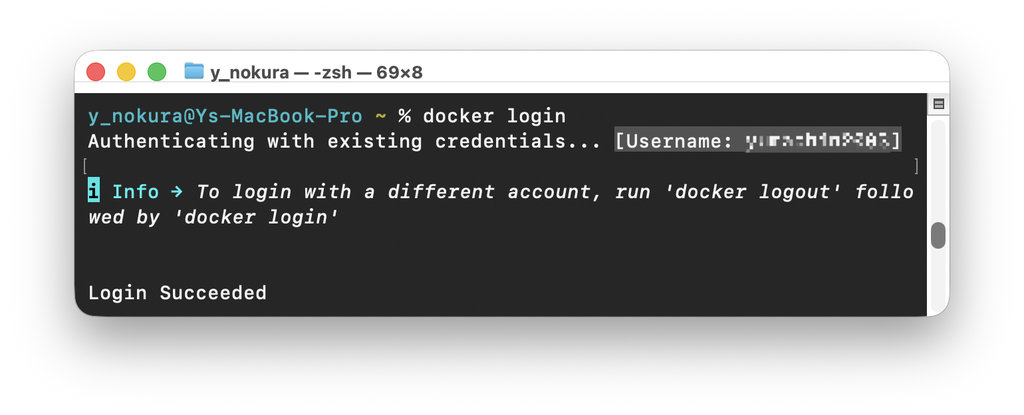

または、Linuxの場合`docker info | grep Username`でも確認可。ただしMacではログイン情報がキーチェーンに暗号化して保存されるため確認不可、Windowsでは未検証。

## サーバーでのイメージのプル

非公開リポジトリはあらかじめイメージをプルする必要がある。

**ノート**

公開リポジトリの場合は、ApptainerはDockerリポジトリに直接アクセスできるため、この手順はスキップ可。

```
bash
```

```bash
# docker pull <リポジトリ>:<タグ>
docker pull yumachin2003/shinshu-fesnav-backend:v0
```

## ApptainerでSIFファイルに変換

**Dockerイメージをプル済みの場合**:  
ソースURIのプロコトルを`docker-daemon://`にする。

```
bash
```

```bash
# apptainer build <SIFファイルの出力先> docker-daemon://<リポジトリ>:<タグ>
apptainer build backend.sif docker-daemon://yumachin2003/shinshu-fesnav-backend:v0
```

**Dockerイメージをプルしていない場合**:  
ソースURIのプロコトルを`docker://`にする。

```
bash
```

```bash
# apptainer build <SIFファイルの出力先> docker://<リポジトリ>:<タグ>
apptainer build frontend.sif docker://yumachin2003/shinshu-fesnav-frontend:v0
```

## フロントエンドの静的ファイルの取り出し

あらかじめ静的ファイルを格納するディレクトリを作成しておく。

```
bash
```

```bash
mkdir -p react_static
```

作成したディレクトリに静的ファイルをコピーする。

```
bash
```

```bash
apptainer exec frontend.sif cp -r /usr/share/nginx/html/. ./react_static/
```

フロントエンドの静的ファイル

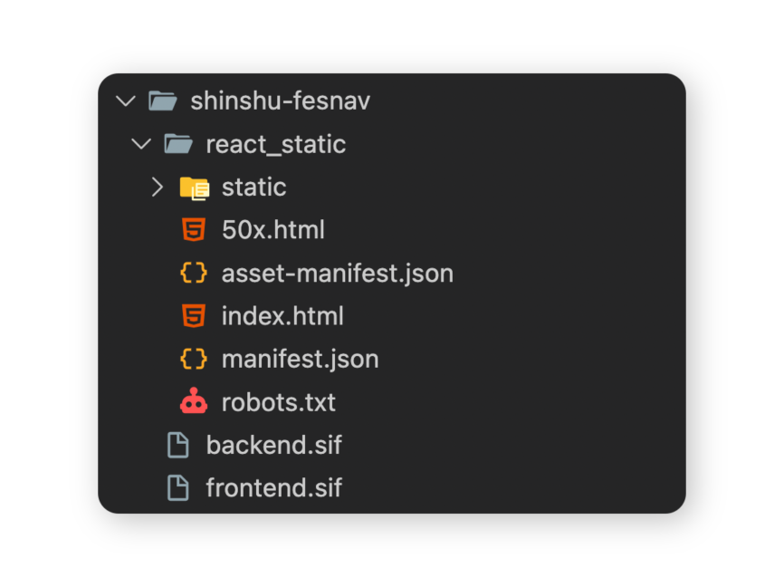

**重要**

`index.html`が静的ファイルの核になるので、必ず生成されているかを確認すること。`ls ./react_static/`で確認可。

**ノート**

変更がフロントエンドのみの場合、イメージのプルと静的ファイルの取り出しのみで変更が適用される。

## インスタンスの起動

インスタンスを起動することにより、実行用の箱が生成され、バックグラウンドで実行可能になる。

```
bash
```

```bash
# apptainer instance start <SIFのソース> <インスタンス名>
apptainer instance start \
  --bind $PWD/react_static:/app/client_build \
  --bind $PWD/server.crt:/app/server.crt \
  --bind $PWD/server.key:/app/server.key \
  backend.sif shinshu-fesnav
```

- `--bind`: **バインドマウント**といい、コンテナ内部とサーバー側のディレクトリをリダイレクトさせている。`:`の左側（`$PWD/react_static`）がサーバー側のディレクトリ、右側（`/app/client_build`）がコンテナ内のディレクトリになる。

**ノート**

バインドマウントを実装する利点としては、以下の二つ。

1. 中身のデータや設定ファイルだけを外から差し込めるので、修正のたびにビルドし直す必要がなくなる。
2. コンテナの中で書き込んだデータはコンテナを消すと削除されるが、外のフォルダ（サーバー側）に実体が保存される。
- `$PWD`: 現在の作業ディレクトリの絶対パスを表す環境変数。コンテナツールは相対パスでエラーが起こることが多いため、絶対パスで表記することが重要である。

`INFO: instance started successfully`と表示されたら正常に起動完了。

**Apptainerのインスタンスの確認と停止**

**実行中のインスタンスの確認**は以下のコマンドで可能である。

```
bash
```

```bash
apptainer instance list
```

また、**インスタンスの停止**コマンドは以下の通り。

```
bash
```

```bash
apptainer instance stop <インスタンス名>
```

- 全てのインスタンスを停止したい場合は、`<インスタンス名>`を`--all`にする。

## Webサーバーの起動

`apptainer exec`コマンドで`shinshu-fesnav`インスタンス内でサーバー起動のコマンドを実行する。本番環境のサーバーはGunicornのため、`gunicorn`コマンドで起動する。

```
bash
```

```bash
apptainer exec instance://shinshu-fesnav \
  sh -c "\
    cd /app && \
    export STATIC_FOLDER=/app/client_build　&& \
    export FLASK_ENV=production && \
    nohup gunicorn \
      --workers 4 \
      --bind 0.0.0.0:5051 \
      --certfile=$PWD/server.crt \
      --keyfile=$PWD/server.key \
      'app:create_app()' \
      > $PWD/server.log 2>&1 &"
```

- `instance://...`: 「インスタンスの起動」の項で起動したインスタンス名を指定する。
- `sh -c "..."`: インスタンス内でコマンドを実行できるように、新規シェルセッションを生成する。
- `export STATIC_FOLDER=/app/client_build`: `STATIC_FOLDER`環境変数の設定。静的フォルダのパスを指定し、`__init__.py`で使用される。
- `export FLASK_ENV=production`: `FLASK_ENV`環境変数の設定。こちらも`__init__.py`で使用され、`production`にすることで本番環境であることが宣言される。
- `nohup`: ターミナルを閉じても実行させるようにする命令。
- `gunicorn ... 'app:create_app()'`: サーバーの起動コマンド本核。
  - `--workers`: スレッド数を指定。

  **スレッドとは**

  リクエストを並列処理するための実行単位のこと。初期状態では1（シングル）スレッドであり、１人のユーザーが重いリクエストを受け取った数秒間、他のユーザーがアクセスすると「待機中（グルグル）」になってしまう。そこで、スレッド数を増やすことでPythonのプログラムを4つ起動し、並列で待ち構えさせる。しかし、スレッドを増やしすぎるとメモリ（RAM）を浪費し、CPUが管理しきれず逆に遅くなってしまう。Gunicornの公式推奨式は **(CPUのコア数 × 2) + 1** であり、一般的なサーバー（1〜2コア）で動かすには4スレッド程度が安全である。
  - `--bind`: リッスンポートの指定。`0.0.0.0`で任意のIPアドレス、`:5051`で5051万ポートをリッスン。
  - `--certfile`: SSL証明書の指定。
  - `--keyfile`: 秘密鍵の指定。
- `> $PWD/server.log 2>&1`: ログ（`server.log`）をルートディレクトリに書き出す。`2>&1`は標準エラー出力（`2`）を標準出力（`1`）にリダイレクト（`&>`）し、ログにエラーも含めるようにする設定。
- 末尾の`&`: バックグラウンド実行。これがないとターミナルが操作できなくなる。

**自己証明書と秘密鍵の生成**

パスワードやメールアドレスのような機密情報を扱うには接続の暗号化（HTTPS）が必須であり、そのために必要なSSL証明書と秘密鍵は公的な機関が発行するものが必要であるが、動作確認用に[OpenSSL](https://www.openssl.org/)で自己証明書を生成することができる。

```
bash
```

```bash
$ openssl req -new -newkey rsa:2048 -days 365 -nodes -x509 \
  -keyout server.key -out server.crt
```

このコマンドを実行中にいくつか質問されるが、一般的には以下のように入力する。

1. Country Name (2 letter code) [XX]: `JP`
2. State or Province Name (full name) []: `Nagano` （都道府県）
3. Locality Name (eg, city) []: `Ueda` （市区町村）
4. Organization Name (eg, company) []: `SekiZemiNokuraTeam`（組織名）
5. Organizational Unit Name (eg, section) []: （空欄で可）
6. Common Name (e.g. server FQDN) []: （サーバーのIPアドレス）
7. Email Address []: `j22069yn@stu.nagano.ac.jp`（空欄で可）

入力が完了すると、`server.crt`（証明書）と`server.key`（秘密鍵）が生成される。自己証明書のサイトに接続するとほぼ全てのブラウザで警告画面が出るが、「このWebサイトを閲覧」や「〜〜にアクセスする（安全ではありません）」などをクリックすると閲覧は可能である。

不正な証明書による警告画面

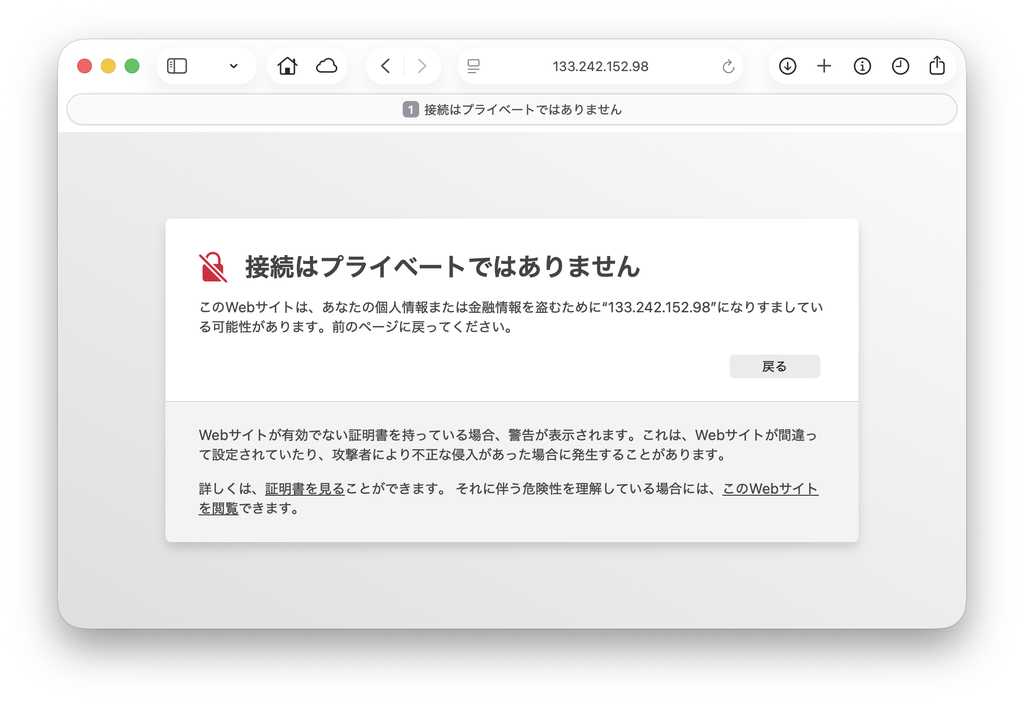

# 実行結果の確認

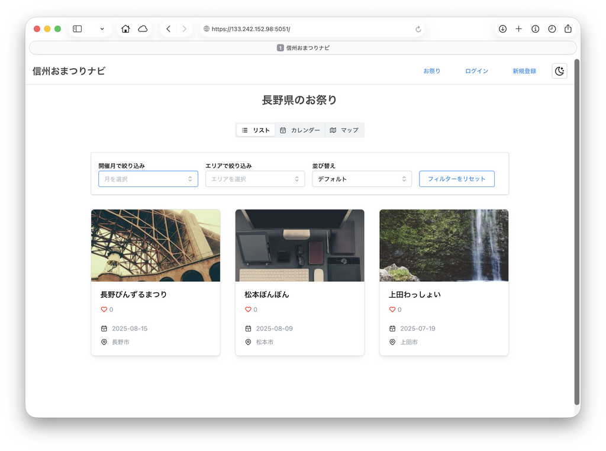

※画像をクリックでページにジャンプできます